# main_analyse

Roberto Quezada GArcia

2026-07-25

## R Markdown

**Analyse des données** Votre prénom et nom : Roberto Quezada Garcia/ Votre numéro d’étudiant : 24120461/ Trimestre d’inscription : été 2026/ Date d’envoi : 26 juillet 2026/ Direction github du projet : https://github.com/RobertoQG/projet_teluq

```r
source("classe_outils.R")
library(magrittr)
outils <- Outils$new()
```

## Chemin et importation des données

```
##   nerprun pres        x        y
## 1 absence    0 270759.0 487866.6
## 2 absence    0 270761.4 487842.0
## 3 absence    0 270695.9 487873.3
## 4 absence    0 270698.5 487881.4
## 5 absence    0 270727.3 487932.8
## 6 absence    0 270733.6 487936.8
```

## Préparation des données et analyse des modèles

Cette étape vise à préparer un jeu de données tabulaire unique, combinant les points de présence/absence du nerprun et les valeurs des variables environnementales correspondantes, afin de pouvoir entraîner rapidement les quatre modèles (RF, GLM, SVM, GAM) pour chacun d’eux. Une fois les performances des modèles obtenues, seul le meilleur modèle sera ensuite utilisé pour produire la carte de prédiction finale.

Les principales étapes de préparation sont les suivantes :

- **Extraction des valeurs environnementales** (`terra::extract`) : les valeurs des variables du raster sont extraites aux coordonnées (x, y) de chaque point d’occurrence, afin d’associer à chaque observation de présence/absence ses conditions environnementales locales.
- **Retrait des valeurs manquantes** (`complete.cases`) : les points situés en dehors de l’étendue du raster, ou pour lesquels une ou plusieurs variables environnementales sont manquantes (NA), sont exclus afin d’éviter des erreurs lors de l’entraînement des modèles.
- **Construction de la formule du modèle** : la formule est générée dynamiquement à partir des noms des couches du raster (`names(monRaster)`), ce qui rend le code flexible advenant un ajout ou un retrait de variables environnementales dans le stack, sans devoir modifier manuellement la formule.
- **Séparation entraînement/test (split 70/30)** : les données sont divisées aléatoirement en un jeu d’entraînement (70 %) et un jeu de test (30 %), avec une valeur fixe (`set.seed(42)`) pour assurer la reproductibilité des résultats. Le jeu de test, indépendant de l’entraînement, permet d’évaluer la performance réelle de chaque modèle sur des données qu’il n’a jamais vues, plutôt que de mesurer uniquement sa capacité à s’ajuster aux données d’entraînement.
- **Fonction de mesure du temps d’exécution** (`mesureTemps`) : chaque algorithme est entraîné à l’aide de cette fonction décoratrice, ce qui permet de documenter et comparer le temps de calcul requis par chaque approche, un critère pertinent lorsque plusieurs modèles doivent être testés de façon répétée.

```r
set.seed(42)
valeursEnv <- terra::extract(monRaster, mesPoints[, c("x", "y")])
donneesModele <- cbind(mesPoints, valeursEnv[, -1])
donneesModele <- donneesModele[complete.cases(donneesModele), ]

variablesEnv <- names(monRaster)
formule <- as.formula(paste("pres ~", paste(variablesEnv, collapse = " + ")))


indexEntrainement <- sample(seq_len(nrow(donneesModele)), size = 0.7 * nrow(donneesModele))
entrainement <- donneesModele[indexEntrainement, ]
test <- donneesModele[-indexEntrainement, ]

mesureTemps <- outils$mesureTempsDeco
```

## Fonction pour calculer les métriques des modèles

Afin de comparer objectivement la performance des quatre modèles, une fonction générique a été développée pour calculer un ensemble de métriques d’évaluation complémentaires plutôt que de se fier à une seule mesure. Chaque métrique apporte une information différente sur la qualité du modèle :

- **AUC (Area Under the Curve)** : mesure la capacité globale du modèle à discriminer les présences des absences, indépendamment d’un seuil de classification. C’est une métrique standard et largement utilisée en modélisation de distribution d’espèces, puisqu’elle évalue la qualité du classement des probabilités prédites plutôt qu’une classification binaire arbitraire.
- **Seuil optimal (méthode de Youden)** : les modèles produisent une probabilité continue de présence, qu’il faut convertir en prédiction binaire (présence/absence) pour calculer plusieurs des métriques suivantes. La méthode de Youden a été choisie car elle sélectionne le seuil qui maximise simultanément la sensibilité et la spécificité, ce qui correspond directement à la maximisation du TSS
- **Sensibilité et spécificité** : évaluent respectivement la capacité du modèle à bien détecter les présences réelles (éviter les faux négatifs) et les absences réelles (éviter les faux positifs). Ces deux métriques sont essentielles en écologie, car un modèle peut afficher une bonne précision globale tout en étant biaisé vers une seule classe si les données sont déséquilibrées.
- **TSS (True Skill Statistic)** : combine sensibilité et spécificité en une seule valeur (sensibilité + spécificité − 1). Le TSS est privilégié en modélisation de distribution d’espèces car, contrairement au Kappa, il n’est pas influencé par la prévalence (le ratio présence/absence) des données, ce qui le rend plus fiable pour comparer des modèles entre eux.
- **Kappa de Cohen** : mesure l’accord entre les prédictions et les observations en corrigeant pour l’accord attendu par le simple hasard. Il complète le TSS en offrant une autre perspective sur la fiabilité des prédictions binaires du modèle.
- **Précision globale** : indique simplement la proportion totale de prédictions correctes (présences et absences confondues). Bien que facile à interpréter, cette métrique est incluse à titre indicatif seulement, car elle peut être trompeuse si les classes sont déséquilibrées — d’où l’importance de l’analyser conjointement avec la sensibilité, la spécificité et le TSS.

Cette fonction a été construite comme une alternative rapide aux métriques d’évaluation calculées automatiquement

```r
calculerMetriques <- function(predictions, observations) {
  roc_obj <- pROC::roc(observations, predictions, quiet = TRUE)

  # Seuil optimal selon Youden (= max de TSS = sensibilité + spécificité - 1)
  meilleurSeuil <- pROC::coords(roc_obj, "best", best.method = "youden",
                                 ret = c("threshold", "sensitivity", "specificity"))

  sensibilite <- meilleurSeuil$sensitivity
  specificite <- meilleurSeuil$specificity
  tss <- sensibilite + specificite - 1

  predBinaire <- ifelse(predictions >= meilleurSeuil$threshold, 1, 0)

  matriceConf <- table(
    Observe = factor(observations, levels = c(0, 1)),
    Predit  = factor(predBinaire, levels = c(0, 1))
  )

  vp <- matriceConf["1", "1"]
  vn <- matriceConf["0", "0"]
  fp <- matriceConf["0", "1"]
  fn <- matriceConf["1", "0"]

  n <- vp + vn + fp + fn
  accord_observe <- (vp + vn) / n
  accord_hasard <- ((vp + fp) * (vp + fn) + (fn + vn) * (fp + vn)) / n^2
  kappa <- (accord_observe - accord_hasard) / (1 - accord_hasard)

  data.frame(
    AUC = as.numeric(roc_obj$auc),
    seuil = as.numeric(meilleurSeuil$threshold),
    sensibilite = sensibilite,
    specificite = specificite,
    TSS = tss,
    Kappa = kappa,
    precision_globale = accord_observe
  )
}
```

## Performance des modèles

Afin de prédire la probabilité de présence du nerprun (*nerprun bourdaine*), quatre algorithmes de modélisation de la distribution d’espèces ont été comparés : Random Forest, GLM, SVM et GAM. Ces quatre approches ont été retenues car elles reposent sur des hypothèses statistiques différentes (linéaire, non linéaire, paramétrique, non paramétrique) et sont couramment utilisées en modélisation de niche écologique, ce qui permet de comparer leurs performances et de sélectionner celle qui capte le mieux la relation entre les variables environnementales et la présence de l’espèce.

### Random Forest

Le Random Forest a été choisi pour sa capacité à modéliser des relations non linéaires et des interactions complexes entre variables environnementales sans devoir les spécifier a priori. Il est aussi robuste face au surapprentissage grâce à l’agrégation de multiples arbres de décision, et peu sensible à la présence de variables corrélées ou peu informatives.

```r
entrainementRF <- entrainement
entrainementRF$pres <- as.factor(entrainementRF$pres)


rfModele <- mesureTemps(randomForest::randomForest)(formule, data = entrainementRF)
```

[output not shown]

```r
predRF <- predict(rfModele, newdata = test, type = "prob")[, "1"]
```

### Modèle linéaire généralisé (GLM)

Le GLM a été inclus comme modèle de référence classique en modélisation de distribution d’espèces. Sa simplicité et son interprétabilité (coefficients associés à chaque variable) en font un bon point de comparaison pour évaluer si les relations entre les variables environnementales et la présence du nerprun sont essentiellement linéaires, ou si des approches plus flexibles comme le Random Forest ou le GAM apportent un gain de performance réel.

```r
glmModele <- mesureTemps(stats::glm)(formule, data = entrainement, family = binomial)
```

[output not shown]

```r
predGLM <- predict(glmModele, newdata = test, type = "response")
```

### Machine à vecteurs de support (SVM)

Le SVM a été retenu pour sa capacité à séparer efficacement les classes (présence/absence) même lorsque la frontière de décision est complexe et non linéaire, grâce à l’utilisation de noyaux. Cet algorithme performe généralement bien avec un nombre modéré d’observations et de variables, ce qui correspond au contexte de ce jeu de données.

```r
entrainementSVM <- entrainement
entrainementSVM$pres <- as.factor(entrainementSVM$pres)

svmModele <- mesureTemps(e1071::svm)(formule, data = entrainementSVM, probability = TRUE)
```

[output not shown]

```r
predSVM <- attr(predict(svmModele, newdata = test, probability = TRUE), "probabilities")[, "1"]
```

### Modèle additif généralisé (GAM)

Le GAM a été choisi comme intermédiaire entre le GLM et le Random Forest : il permet de modéliser des relations non linéaires entre chaque variable environnementale et la probabilité de présence (via des fonctions de lissage), tout en conservant une structure additive plus interprétable qu’un modèle de type “boîte noire” comme le Random Forest ou le SVM. C’est une approche fréquemment utilisée en écologie pour ce type de compromis entre flexibilité et interprétabilité.

```r
formuleGAM <- as.formula(paste("pres ~", paste0("s(", variablesEnv, ")", collapse = " + ")))
gamModele <- mesureTemps(mgcv::gam)(formuleGAM, data = entrainement, family = binomial)
```

[output not shown]

```r
predGAM <- predict(gamModele, newdata = test, type = "response")
```

## Comparaison des modèles

Les performances de ces quatre modèles sont comparées dans la section suivante à l’aide de plusieurs métriques d’évaluation (AUC, TSS, Kappa, sensibilité, spécificité et précision globale), afin de sélectionner objectivement le modèle le plus performant pour prédire la probabilité de présence du nerprun.

On regroupe les métriques d’évaluation (AUC, Kappa, sensibilité, spécificité, seuil, TSS, etc.) de chaque modèle dans un seul tableau, pour pouvoir les comparer facilement.

```r
metriquesRF  <- calculerMetriques(predRF,  test$pres)
metriquesGLM <- calculerMetriques(predGLM, test$pres)
metriquesSVM <- calculerMetriques(predSVM, test$pres)
metriquesGAM <- calculerMetriques(predGAM, test$pres)

tableauComparatif <- do.call(rbind, list(
  cbind(modele = "RF",  metriquesRF),
  cbind(modele = "GLM", metriquesGLM),
  cbind(modele = "SVM", metriquesSVM),
  cbind(modele = "GAM", metriquesGAM)
))

knitr::kable(tableauComparatif, digits = 3, caption = "Comparaison des modèles SDM")
```

Comparaison des modèles SDM

| modele | AUC | seuil | sensibilite | specificite | TSS | Kappa | precision_globale |
| --- | --- | --- | --- | --- | --- | --- | --- |
| RF | 0.999 | 0.123 | 0.996 | 0.994 | 0.990 | 0.976 | 0.994 |
| GLM | 0.985 | 0.282 | 0.987 | 0.962 | 0.949 | 0.870 | 0.966 |
| SVM | 0.996 | 0.247 | 0.983 | 0.989 | 0.972 | 0.951 | 0.988 |
| GAM | 0.998 | 0.195 | 0.987 | 0.984 | 0.972 | 0.939 | 0.985 |

[output not shown]

**Meilleur modèle : RF** — il obtient les meilleurs scores sur l’ensemble des métriques (AUC, TSS, Kappa, précision globale, sensibilité et spécificité), ce qui en fait le choix le plus performant pour cette analyse.

## Sélection et ajustement final du meilleur

```r
nomMeilleurModele <- tableauComparatif$modele[which.max(tableauComparatif$AUC)]
cat("Le meilleur modèle est :", nomMeilleurModele, "/n")
```

```
## Le meilleur modèle est : RF /n
```

```r
cat("AUC =", max(tableauComparatif$AUC), "/n")
```

```
## AUC = 0.9994648 /n
```

## Prédiction de la carte de distribution prédite

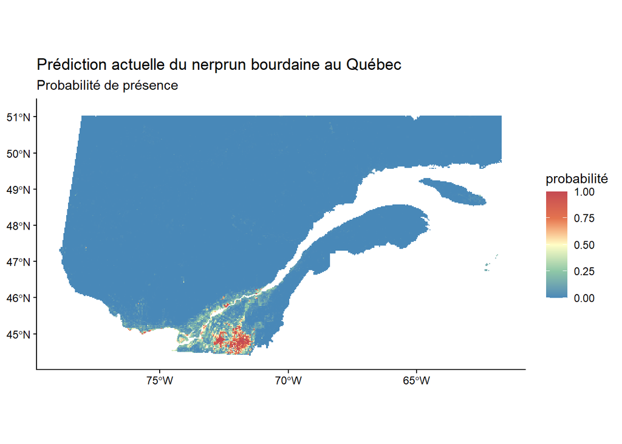

## Prediction pour le future avec les trois scenarios

Les projections climatiques futures utilisées pour cette analyse proviennent des données d’Ouranos, le consortium de référence en scénarios climatiques régionalisés pour le Québec. Trois scénarios socio-économiques partagés (SSP) sont considérés afin de représenter un gradient de trajectoires d’émissions de gaz à effet de serre : SSP245 (émissions modérées), SSP370 (émissions élevées) et SSP585 (émissions très élevées, scénario le plus pessimiste). Ces trois scénarios permettent d’évaluer la sensibilité de la répartition potentielle du nerprun bourdaine à différentes intensités de changements climatiques.

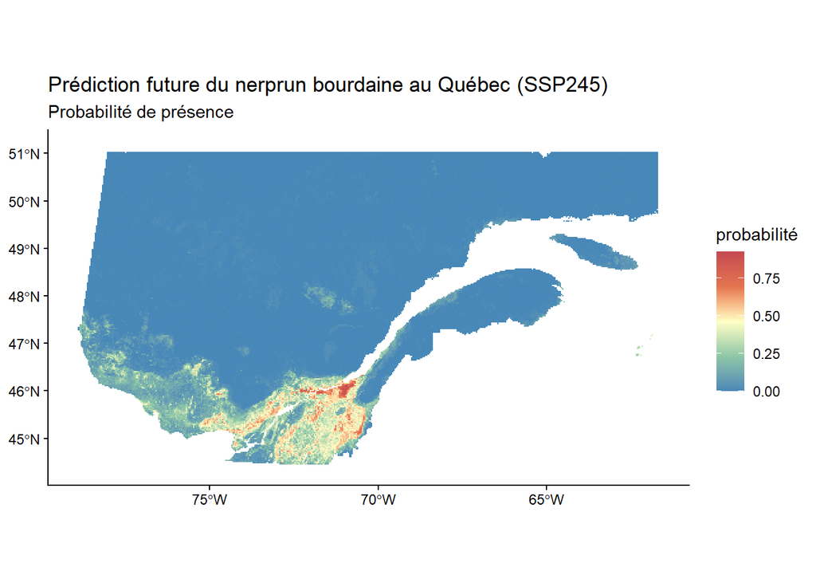

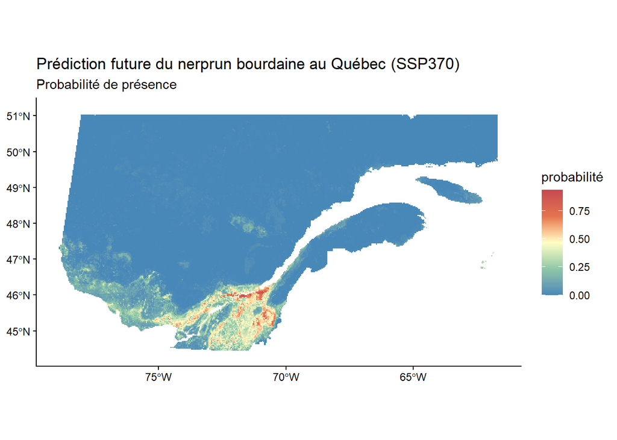

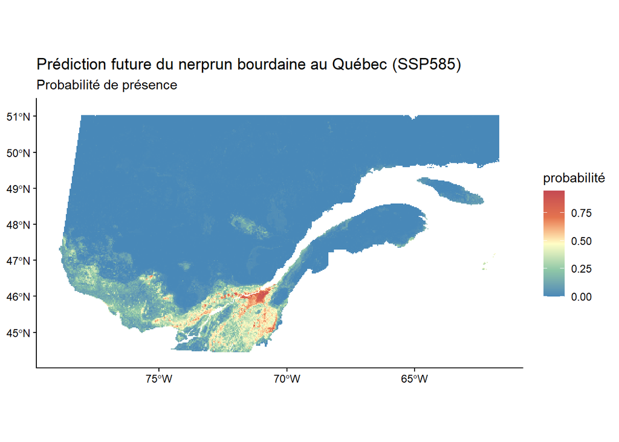